# Lab 6 Assignment

## Problem 1:

$X \sim U(0,1)$ and $Y \sim U(0,1)$.

Plot the joint distribution of X & Y such that $X+Y < 1$

1. First make a large number of samples from $X \sim U(0,1)$ and $Y \sim U(0,1)$ and plot X & Y and then plot the samples below the line $x+y = 1$ .

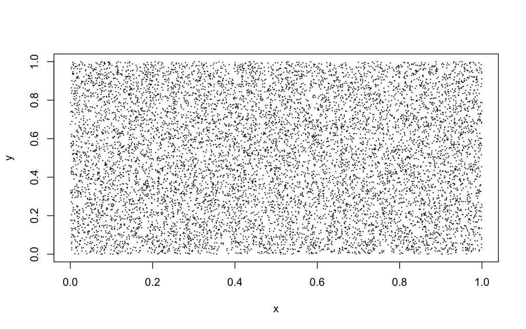

```r
df <- data.frame(x = runif(10000), y = runif(10000))
plot(df, cex=.1)
```

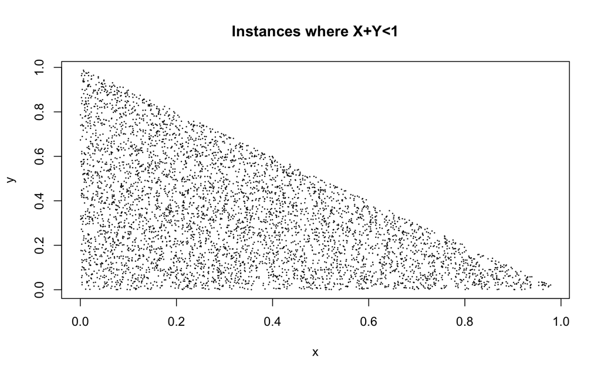

```r
df2 <- df[rowSums(df) < 1,]
plot(df2, cex=.1, main='Instances where X+Y<1')
```

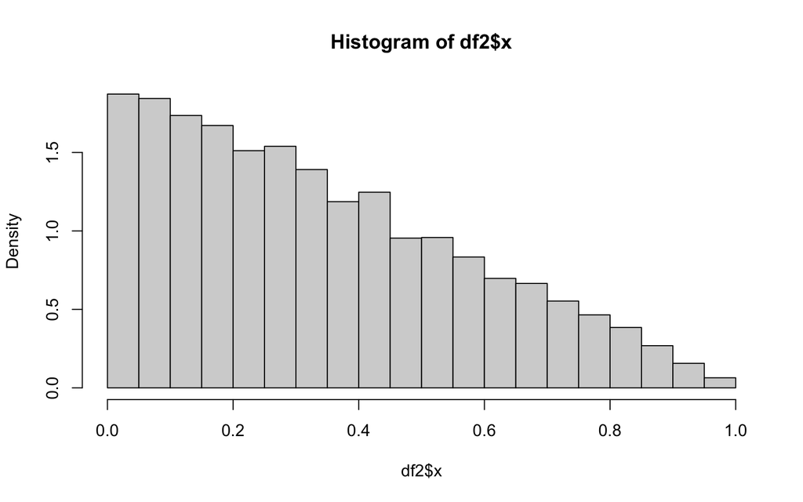

```r
hist(df2$x, prob=T)
```

4. Find the marginal distribution of Y by hand and making a probability histogram. Compare whether these are the same. (Hint: think about the limits of X and Y according to $0<X+Y<1$)

$$\begin{aligned}
f_{Y}(y) = \int_{0}^1f_{XY}(x,y)dy
\end{aligned}$$

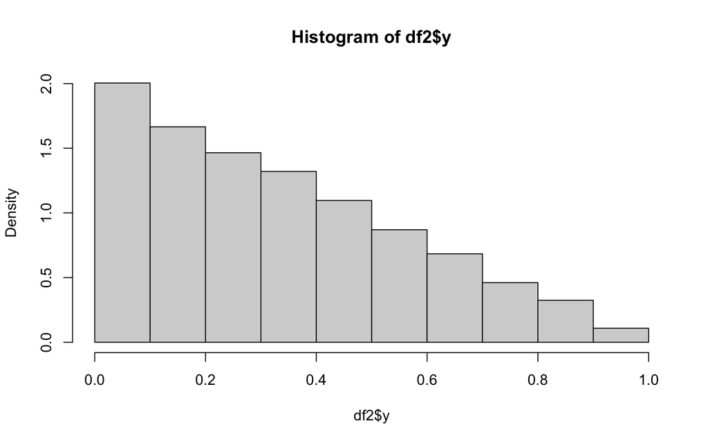

```r
hist(df2$y, prob=T)
```

## Problem 2: Joint distributions and Conditional Expectations.

A CDF is defined by

$$\begin{aligned}
F(x,y) &= \begin{cases} Cx^2y(x+y^2) \quad (0 \leq y \leq 3, 0 \leq
x \leq 2)\\
0 \quad (otherwise)
\end{cases}
\end{aligned}$$

1. Find the joint probability density function.
2. Find the value of $C$.
3. Find the Marginal density of $X$
4. Find the Conditional expectation $E(Y|X)$
5. Find the probability $Pr(X\leq Y)$

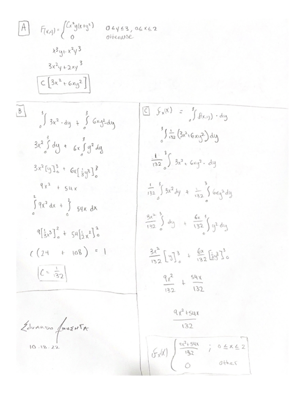

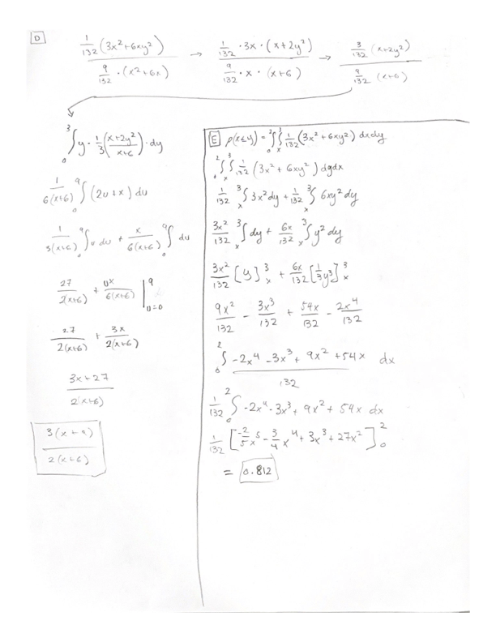

## Problem 3: TRY (no need to submit)

1. Do this with a data frame. Two columns, one for X and one for Y. use *floor()* function.

   *floor function:* https://en.wikipedia.org/wiki/Floor_and_ceiling_functions
2. Find the median $Y|X$ and plot. (You can use the *aggregate()* function.). Comment.
3. Find the standard deviation of $Y|X$ and plot. (You can use the *aggregate()* function.). Comment.